# Exploration of the Ford go-bike trips dataset

## Introduction

The dataset at hand provides valuable information regarding the usage of a bike-sharing system in the greater San Francisco Bay area. This dataset contains data on individual rides made by users of the bike-sharing system, which can be analyzed to gain insights into patterns of usage and user behavior. With information such as the duration of each ride, the starting and ending points of each trip, and the type of bike used, this dataset is an important resource for anyone looking to understand the dynamics of bike-sharing systems and their impact on transportation in urban areas.

The analysis of this dataset seeks to explore the individual variables to get an idea of their distribution, as well as know the relationship between these variables with on another in order to answer some of, but not limited to the following questions below:

- What age group use the Ford Bike sharing services the most?.
- What percentage of riders are males, females or have undefined genders?.
- What day of the week do we see more rides occur?.
- What are the top 10 least visited start stations?.
- Is there a relationship between the age of users and the general duration of rides?. How does the age distribution among user types compare?.
- What proportion of each user types are made up of male, female and other genders?
- What is the distribution by age of riders who use the bike sharing services on diffrent days of the week?
- Are male rides really spending more time on rides as the cumulative time spent on rides by different genders suggest?

## Table of content

- Preliminary data wrangling

  a. Quality issues observed

  b. Data cleaning process
- Univariate data exploration

  a. Distribution of our variables of interest
- Bivariate data exploration

  a. Relationships between variables of interest
- Multivariate data explorations

  a. Interactions between variables of interest

## Preliminary Wrangling

```python
# import all packages and set plots to be rendered inline
import numpy as np
import pandas as pd
import matplotlib.pyplot as plt
import seaborn as sns
sns.set_style('darkgrid')

%matplotlib inline
```

```python
# loading the go-bike dataset
go_bike_original = pd.read_csv('ford_go_bike_tripdata.csv')
go_bike_original.head()
```

|  | duration_sec | start_time | end_time | start_station_id | start_station_name | start_station_latitude | start_station_longitude | end_station_id | end_station_name | end_station_latitude | end_station_longitude | bike_id | user_type | member_birth_year | member_gender | bike_share_for_all_trip |
| --- | --- | --- | --- | --- | --- | --- | --- | --- | --- | --- | --- | --- | --- | --- | --- | --- |
| 0 | 52185 | 2019-02-28 17:32:10.1450 | 2019-03-01 08:01:55.9750 | 21.0 | Montgomery St BART Station (Market St at 2nd St) | 37.789625 | -122.400811 | 13.0 | Commercial St at Montgomery St | 37.794231 | -122.402923 | 4902 | Customer | 1984.0 | Male | No |
| 1 | 42521 | 2019-02-28 18:53:21.7890 | 2019-03-01 06:42:03.0560 | 23.0 | The Embarcadero at Steuart St | 37.791464 | -122.391034 | 81.0 | Berry St at 4th St | 37.775880 | -122.393170 | 2535 | Customer | NaN | NaN | No |
| 2 | 61854 | 2019-02-28 12:13:13.2180 | 2019-03-01 05:24:08.1460 | 86.0 | Market St at Dolores St | 37.769305 | -122.426826 | 3.0 | Powell St BART Station (Market St at 4th St) | 37.786375 | -122.404904 | 5905 | Customer | 1972.0 | Male | No |
| 3 | 36490 | 2019-02-28 17:54:26.0100 | 2019-03-01 04:02:36.8420 | 375.0 | Grove St at Masonic Ave | 37.774836 | -122.446546 | 70.0 | Central Ave at Fell St | 37.773311 | -122.444293 | 6638 | Subscriber | 1989.0 | Other | No |
| 4 | 1585 | 2019-02-28 23:54:18.5490 | 2019-03-01 00:20:44.0740 | 7.0 | Frank H Ogawa Plaza | 37.804562 | -122.271738 | 222.0 | 10th Ave at E 15th St | 37.792714 | -122.248780 | 4898 | Subscriber | 1974.0 | Male | Yes |

**Making a copy of the dataset before cleaning and analysing it**

```python
go_bike = go_bike_original.copy()
```

**Note**: Because the ages of riders, as well as the days of which in which the rides occured will be relevant to this analysis, future engineering to obtaint this data (columns) will be done at this point

```python
# Checking all existing columns
go_bike.columns
```

```
Index(['duration_sec', 'start_time', 'end_time', 'start_station_id',
       'start_station_name', 'start_station_latitude',
       'start_station_longitude', 'end_station_id', 'end_station_name',
       'end_station_latitude', 'end_station_longitude', 'bike_id', 'user_type',
       'member_birth_year', 'member_gender', 'bike_share_for_all_trip'],
      dtype='object')
```

```python
# converting the start_time column to datetime values
go_bike['start_time'] = pd.to_datetime(go_bike['start_time'])

# Creating a new column named `age`.
go_bike['age'] = 2019 - go_bike['member_birth_year']

# Creating the day of week (dow) column from the 'start_time' column
go_bike['dow'] = go_bike['start_time'].dt.dayofweek
```

```python
# Replacing all the numbers in the dow column to appropriate names of the days of the week.

go_bike.replace({'dow':[0, 1, 2, 3, 4, 5, 6]},
                {'dow': ['monday','tuesday','wednesday','thursday','friday','saturday','sunday']},
                inplace = True)
```

```python
# Changing the datatype of the newly generated columns
day_order = ['monday','tuesday','wednesday','thursday','friday','saturday','sunday']
day_cat = pd.api.types.CategoricalDtype(ordered = True, categories = day_order)

go_bike['dow'] = go_bike['dow'].astype(day_cat)
```

```python
go_bike.info()
```

```
<class 'pandas.core.frame.DataFrame'>
RangeIndex: 183412 entries, 0 to 183411
Data columns (total 18 columns):
 #   Column                   Non-Null Count   Dtype
---  ------                   --------------   -----
 0   duration_sec             183412 non-null  int64
 1   start_time               183412 non-null  datetime64[ns]
 2   end_time                 183412 non-null  object
 3   start_station_id         183215 non-null  float64
 4   start_station_name       183215 non-null  object
 5   start_station_latitude   183412 non-null  float64
 6   start_station_longitude  183412 non-null  float64
 7   end_station_id           183215 non-null  float64
 8   end_station_name         183215 non-null  object
 9   end_station_latitude     183412 non-null  float64
 10  end_station_longitude    183412 non-null  float64
 11  bike_id                  183412 non-null  int64
 12  user_type                183412 non-null  object
 13  member_birth_year        175147 non-null  float64
 14  member_gender            175147 non-null  object
 15  bike_share_for_all_trip  183412 non-null  object
 16  age                      175147 non-null  float64
 17  dow                      183412 non-null  category
dtypes: category(1), datetime64[ns](1), float64(8), int64(2), object(6)
memory usage: 24.0+ MB
```

```python
go_bike.member_birth_year.sort_values()
```

```
27370     1878.0
72711     1900.0
41319     1900.0
173711    1900.0
94616     1900.0
           ...
183354       NaN
183356       NaN
183363       NaN
183371       NaN
183402       NaN
Name: member_birth_year, Length: 183412, dtype: float64
```

The birth year 1878 and 1900 seem out of place.

```python
# Columns where null values exist
go_bike.isnull().any()
```

[output not shown]

```python
display(go_bike[go_bike.member_birth_year.isnull()].shape)
display(go_bike[go_bike.start_station_id.isnull()].shape)
display(go_bike[go_bike.end_station_id.isnull()].shape)
```

[output not shown]

[output not shown]

[output not shown]

```python
# Checking for duplicates
go_bike.duplicated().any()
```

```
False
```

```python
# Confirming actual datatypes
dataset_columns = ['duration_sec', 'start_time', 'end_time', 'start_station_id',
       'start_station_name', 'start_station_latitude',
       'start_station_longitude', 'end_station_id', 'end_station_name',
       'end_station_latitude', 'end_station_longitude', 'bike_id', 'user_type',
       'member_birth_year', 'member_gender', 'bike_share_for_all_trip']

for column in dataset_columns:
    print(column, ":", type(go_bike[column][0]))
```

[output not shown]

### Quality issues observed from visual and programmatic assessment.

- Columns that are irrelevalt to this analysis.
- Missing values of start_station_id, start_station_name, end_station_id, end_station_name. As well as member_gender and member_birth_year.
- Erroneous datatypes (start_station_id, end_station_id, and bike id should be strings. Member_gender and User_type should be categorical datatype. The age column should be in integer datatype.)
- A member with birthyear of 1878. This looks out of order.

## Data cleaning process

### Data quality issue 1:

#### Define: Drop all columns that are irrelevant to this analysis.

#### Code

```python
# Using the drop function to drop all columns which are irrelevant to this analysis.
go_bike = go_bike.drop(['start_station_latitude','start_station_longitude','end_station_latitude',
                        'start_time','end_time','end_station_longitude','member_birth_year',
                        'bike_share_for_all_trip'], axis = 1)
```

#### Test

```python
go_bike.keys()
```

```
Index(['duration_sec', 'start_station_id', 'start_station_name',
       'end_station_id', 'end_station_name', 'bike_id', 'user_type',
       'member_gender', 'age', 'dow'],
      dtype='object')
```

### Data quality issue 2:

#### Define: Drop rows with null values according to the column it occurs.

#### Code

```python
go_bike = go_bike[go_bike.member_gender.notnull()]
go_bike = go_bike[go_bike.start_station_name.notnull()]
```

#### Test

```python
print(go_bike.member_gender.isnull().any())
print(go_bike.start_station_name.isnull().any())
```

```
False
False
```

### Data quality issue 3:

#### Define: Correct the datatypes of columns necessary.

### Code

```python
# Creating a function to convert given columns to categorical datatype
def to_categorical(column, category_list):
    category = pd.api.types.CategoricalDtype(ordered = False, categories = category_list)
    go_bike[column] = go_bike[column].astype(category)
```

```python
# Calling the function above to change the member_gender and user_type columns to categorical datatype
gender_categories = ['Male','Female','Other']
name_of_column = 'member_gender'
to_categorical(column = name_of_column, category_list = gender_categories)

user_categories = ['Customer', 'Subscriber']
column_name = 'user_type'
to_categorical(column = column_name, category_list = user_categories)
```

```python
# Changing the datatypes of the columns start_station_id, end_station_id and bike_id, as well as age column
go_bike[['start_station_id','end_station_id','bike_id']] = go_bike[['start_station_id','end_station_id','bike_id']].astype(str)
go_bike.age = go_bike.age.astype(int)

# changing the values of the start station id and end station id to whole numbers
columns_to_split = ['start_station_id','end_station_id']
for col in columns_to_split:
    go_bike[col] = go_bike[col].apply(lambda x: x.split('.')[0])
```

#### Test

```python
print('member_gender:', go_bike.member_gender.dtypes)
print('bike_id:', type(go_bike.bike_id[0]))
print('age:', type(go_bike.age[0]))
```

```
member_gender: category
bike_id: <class 'str'>
age: <class 'numpy.int32'>
```

### Data Quality issue 4.

#### Define: re-establishing an age limit of 100 years

#### Code

```python
# Querying only recoeds where the rider's age is 100 years old or less

go_bike = go_bike.query('age <= 100')
```

#### Test

```python
# Confirming maximum age limit
go_bike.age.max()
```

```
99
```

> After completion of the preliminary wrangling, i'll go ahead to save the final dataset as a csv file

```python
# Saving the go_bike dataframe as a csv file
go_bike.to_csv('go_bike_clean.csv', index = False)
```

```python
display(pd.read_csv('go_bike_clean.csv').head())
display(go_bike.head())
```

|  | duration_sec | start_station_id | start_station_name | end_station_id | end_station_name | bike_id | user_type | member_gender | age | dow |
| --- | --- | --- | --- | --- | --- | --- | --- | --- | --- | --- |
| 0 | 52185 | 21 | Montgomery St BART Station (Market St at 2nd St) | 13 | Commercial St at Montgomery St | 4902 | Customer | Male | 35 | thursday |
| 1 | 61854 | 86 | Market St at Dolores St | 3 | Powell St BART Station (Market St at 4th St) | 5905 | Customer | Male | 47 | thursday |
| 2 | 36490 | 375 | Grove St at Masonic Ave | 70 | Central Ave at Fell St | 6638 | Subscriber | Other | 30 | thursday |
| 3 | 1585 | 7 | Frank H Ogawa Plaza | 222 | 10th Ave at E 15th St | 4898 | Subscriber | Male | 45 | thursday |
| 4 | 1793 | 93 | 4th St at Mission Bay Blvd S | 323 | Broadway at Kearny | 5200 | Subscriber | Male | 60 | thursday |

|  | duration_sec | start_station_id | start_station_name | end_station_id | end_station_name | bike_id | user_type | member_gender | age | dow |
| --- | --- | --- | --- | --- | --- | --- | --- | --- | --- | --- |
| 0 | 52185 | 21 | Montgomery St BART Station (Market St at 2nd St) | 13 | Commercial St at Montgomery St | 4902 | Customer | Male | 35 | thursday |
| 2 | 61854 | 86 | Market St at Dolores St | 3 | Powell St BART Station (Market St at 4th St) | 5905 | Customer | Male | 47 | thursday |
| 3 | 36490 | 375 | Grove St at Masonic Ave | 70 | Central Ave at Fell St | 6638 | Subscriber | Other | 30 | thursday |
| 4 | 1585 | 7 | Frank H Ogawa Plaza | 222 | 10th Ave at E 15th St | 4898 | Subscriber | Male | 45 | thursday |
| 5 | 1793 | 93 | 4th St at Mission Bay Blvd S | 323 | Broadway at Kearny | 5200 | Subscriber | Male | 60 | thursday |

## Univariate Exploration

> Here we shall be looking at various individual variables to get an idea of their general distribution and check to see if there any outliers that are present in the plot.

#### Question 1:

What is the Age distributions of the riders? What age group use the services of Go_Bike the most?

```python
go_bike.columns
```

```
Index(['duration_sec', 'start_station_id', 'start_station_name',
       'end_station_id', 'end_station_name', 'bike_id', 'user_type',
       'member_gender', 'age', 'dow'],
      dtype='object')
```

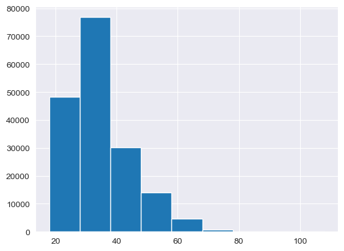

```python
# Plotting a histogram chart of the age column to see its distribution
bins = np.arange(go_bike['age'].min(), go_bike['age'].max()+10, 10)

plt.hist(data = go_bike, x = 'age', bins = bins)
plt.show();
```

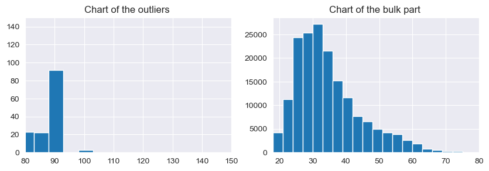

```python
plt.figure(figsize = [10, 3])

plt.subplot(1, 2, 1)
bins = np.arange(go_bike['age'].min(), go_bike['age'].max()+5, 5)
plt.hist(data = go_bike, x = 'age', bins = bins)
plt.xlim((80,150))
plt.ylim((0,150))
plt.title('Chart of the outliers ')

plt.subplot(1, 2, 2)
bins = np.arange(go_bike['age'].min(), go_bike['age'].max()+3, 3)
plt.hist(data = go_bike, x = 'age', bins = bins)
plt.xlim((18, 80))
plt.title('Chart of the bulk part ')

plt.show();
```

#### Insight 1:

The histogram is right skewed and shows that a majority of riders fall between the ages of 18 and 40 years of age.

#### Question 2:

What percentage of riders are males, females or have undefined genders?

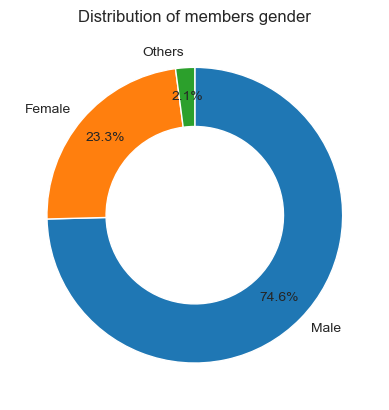

```python
# Plotting a pie chart of member gender
gender_distr = go_bike.member_gender.value_counts()
labels = ['Male','Female','Others']

plt.pie(gender_distr, startangle = 90, counterclock = False, wedgeprops = {'width':0.4},
                                               labels = labels, autopct = '%.1f%%', pctdistance = 0.8)
plt.title('Distribution of members gender')
plt.show()
```

#### Insight 2:

There are far more male riders than there are female riders

#### Question 3:

What are the top 10 least visited start stations?

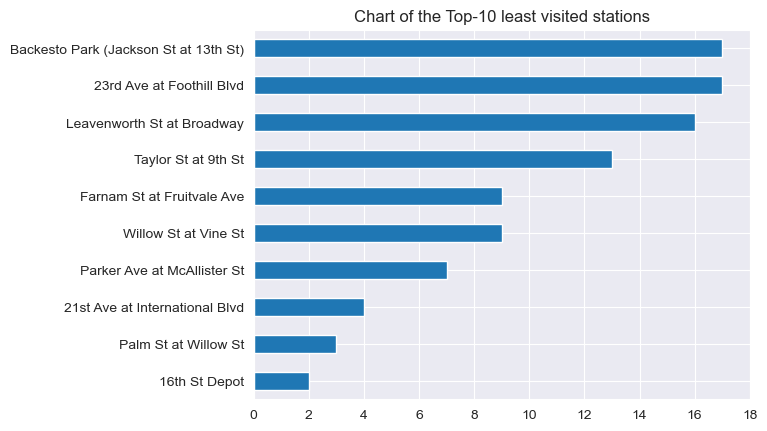

```python
# The least visited stations are the start stations from which rides have commenced the least
least_visited_stations = go_bike.start_station_name.value_counts().sort_values().head(10)

xticks = np.arange(0, 18+2, 2)
least_visited_stations.plot(kind = 'barh')
plt.title('Chart of the Top-10 least visited stations')
plt.xticks(xticks)
plt.show()
```

#### Insight 3:

The least visited start station is the stattion on `16th Street Depot`. The station saw only two visitors in the entire duration of the collected data.

#### Question 4:

What is the distribution of ride duration like?

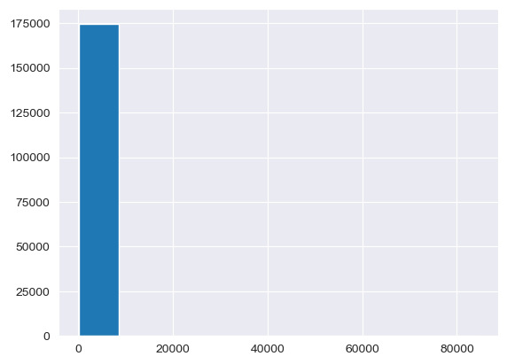

```python
# Plotting a histogram of duration in seconds
plt.hist(data = go_bike, x = 'duration_sec')
plt.show()
```

> As we can see, it seems there are a lot more rides in the lower bound of the ride duration (rides less than say 10000 seconds. We can apply axis log transformation and changing of the bin sizes to get better insight.

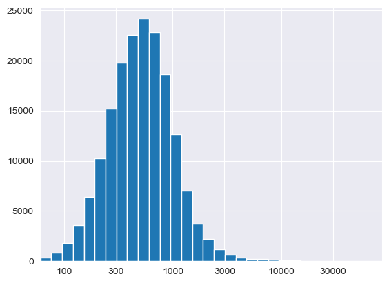

```python
# Changing bin sizes and applying log transformation on the x-axis
xbin = 10 ** np.arange(1.78, 5+0.1, 0.1)
xticks = [100, 300, 1000, 3000, 10000, 30000, 100000]
xlabels = ('{}'.format(v) for v in xticks)

plt.hist(data = go_bike, x = 'duration_sec', bins = xbin)
plt.xscale('log')
plt.xticks(xticks, xlabels)
plt.xlim((60,86000))
plt.show()
```

#### Insight 4:

The chart is unimodal and shows that a good majority of the rides lasted less than 10,000 seconds. But there are a few others that lasted more than that, up to 86,000 seconds. Although, the number of these rides are so infinitesimal that they do not even appear on the chart.

#### Question 5:

What proportion of the User types are subscribers and customers respectively?

```python
users_cat = go_bike.user_type.value_counts(ascending = False)

number_of_users = go_bike.user_type.shape[0]
max_count = users_cat[0]
max_prop = max_count / number_of_users
```

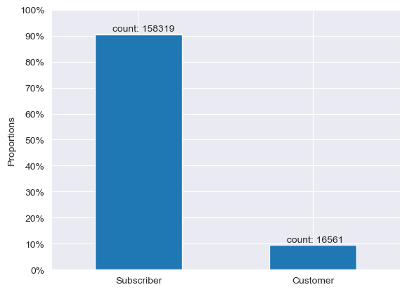

```python
tick_props = np.arange(0, max_prop+0.1, 0.1)
tick_names = [f'{v*100:0.0f}%' for v in tick_props]

users_cat = go_bike.user_type.value_counts()
users_cat.plot(kind = 'bar')
plt.yticks(tick_props * number_of_users, tick_names)
plt.xticks(rotation = 0)
plt.ylabel('Proportions')


for i in range(2):
    count = users_cat[i]
    total_count = f'count: {count}'
    plt.text(i-0.15, count+2000, total_count)
plt.show()
```

#### Question 6:

What day of the week do we see more rides occur?

Here we'll be plotting a seaborn countplot to see the relative distribution of the number of rides taken on different days of the week.

```python
# Preparing the ticks for the relative frequency axis
day_of_week = go_bike.dow.value_counts(ascending = False)
number_of_days = go_bike.dow.shape[0]
max_number = day_of_week[0]
max_proportion = max_number / number_of_days
```

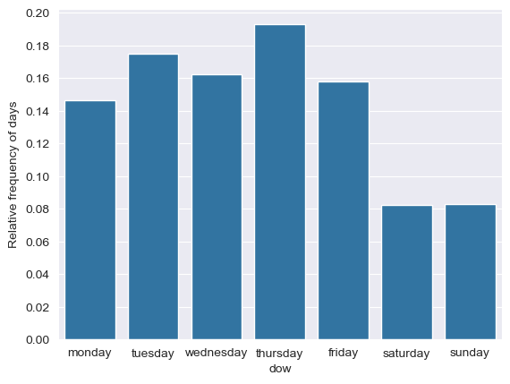

```python
# Plotting the main chart
ytick = np.arange(0, max_proportion +0.02, 0.02)
ytick_names = [f'{v:0.2f}' for v in ytick]
color_scheme = sns.color_palette()[0]

sns.countplot(data = go_bike, x = 'dow', color = color_scheme)
plt.yticks(ytick * number_of_days, ytick_names)
plt.ylabel('Relative frequency of days')
plt.show()
```

#### Insight 6:

Thursdays see the most number of rides than any other days, while saturdays and sundays see the least

### Distributions of our variables of interest.

- The ages of riders had a unimodal distribution, with the histogram skewed t0 the right. Ages generally fell between 18 and 60 years of age, leaving some outliers above the age of 80. Axis limits had to be introduced to focus on the most important part of the chart.
- The distribution of various genders shows that there are more than three times as many male riders as there are female riders. While other unspecified genders make up only a meagre 2.1%.
- Finally, to get a clear picture of the distribution of duration in seconds, a log transformation of the scale had to be done.

## Bivariate Exploration

> In this section, we will be investigating the relationships between pairs of variables which have been earlier discussed in the previous section (Univariate exploration)

#### Question 7:

Is there a relationship between the age of users and the general duration of rides?. Do we see a certain range of age spend more time on rides?

```python
go_bike.shape
```

```
(174880, 10)
```

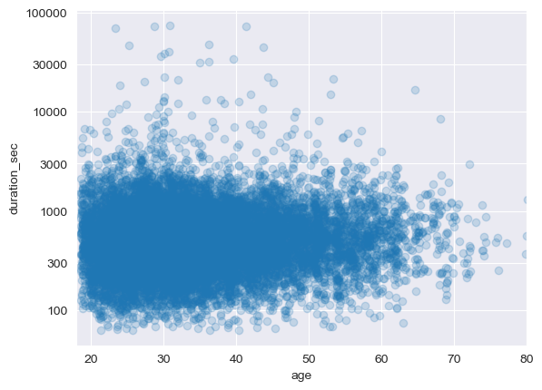

```python
yticks = [100, 300, 1000, 3000, 10000, 30000, 100000]
ylabel = ['{}'.format(v) for v in yticks]

sns.regplot(data = go_bike.sample(17400), x = 'age', y = 'duration_sec', fit_reg = False, x_jitter = 0.4,
           scatter_kws = {'alpha': 0.2})
plt.yscale('log')
plt.xlim([18,80])
plt.yticks(yticks, ylabel)
plt.show()
```

#### Insight 7:

There is no clear correlation between the ages of riders and duration spent on a ride. Although we can see that there are far more persons below the age of 50 who had rides surpassing 30,000 seconds

#### Question 8:

What proportion of each user type are made up of male, female and other genders?

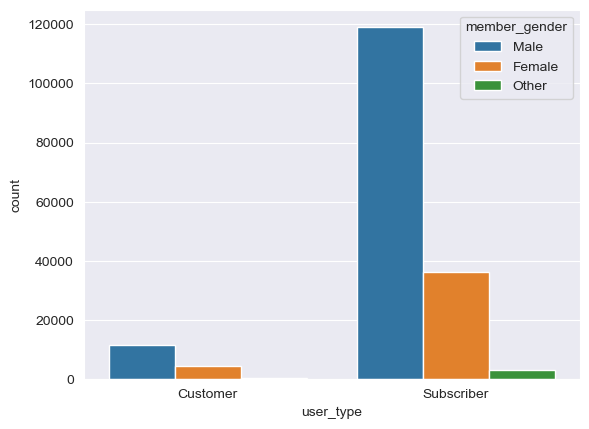

```python
# Plotting a bar chart to display how many times each genders in the user type category used Ford's go-bike service
sns.countplot(data = go_bike, x = 'user_type',  hue = 'member_gender');
```

#### Insight 8:

Generally, there are less than 20,000 customers using the service, while there are at least eight times that number of subcribers.

#### Question 9:

What is the distribution by age of riders who use the bike sharing services on diffrent days of the week?

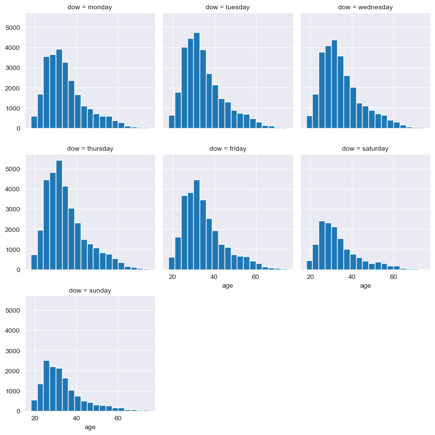

```python
# Plotting a facetted histogram chart for each day of the week for eazy comparison.
bins = np.arange(18, 75+3, 3)

g = sns.FacetGrid(data = go_bike, col = 'dow', col_wrap = 3)
g.map(plt.hist, 'age', bins = bins)
plt.show()
```

#### Insight 9:

The faceted plot above shows the age distribution of riders who use the go_ride bike-sharing service on each day of the week. While thursdays generally has the highest number of rides, saturdays and sundays see the least. One common feature accross all days of the week is that there are typically more riders within the ages of 25 and 35.

#### Question 10:

How does the age distribution among user types compare?

```python
# Creating a function for plotting violinplots. This will be used in the next two sections.

def violin_plot(x_axis, y_axis):
    violin_color = sns.color_palette()[0]
    sns.violinplot(data = go_bike, x = x_axis, y = y_axis, color = violin_color, inner = None)
    plt.show()
```

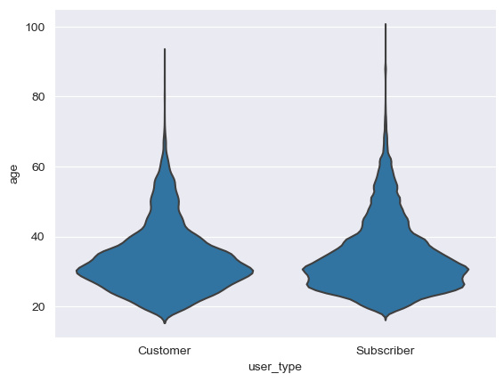

```python
# We can use a violin plot to explore the relationship between the qualitative variable, user_type, and Age.
# Calling the function created above.

violin_plot(x_axis = 'user_type', y_axis = 'age')
```

#### Insight 10:

Both the customer and subscribers all have members who generally fall between the ages of 20 and 40, with very few members outside that age bracket.

#### Question 11:

How does age distribution among the various genders compare?

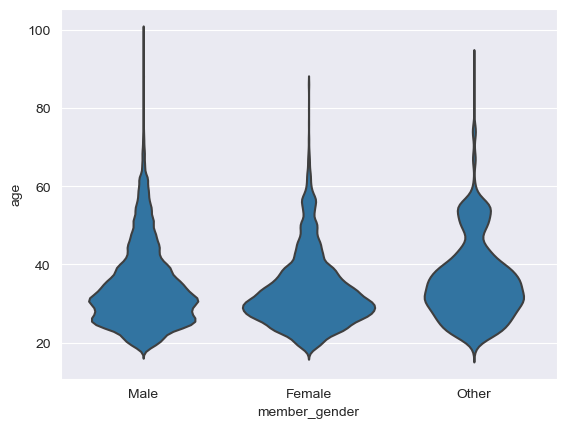

```python
# Calling the violin_plot function created earlier

violin_plot(x_axis = 'member_gender', y_axis = 'age')
```

#### Insight 11:

Similar to the age distribution of various user typed, we see a similar pattern here where a majority of riders fall within the ages of 20 and 40 for all three categoreis of gender also.

#### Question 12:

Which of the genders have spent more time (cumulatively) on rides?

Here we'll have to compare the total time spent on rides by each gender and compare using a bar chart of absolute frequency.

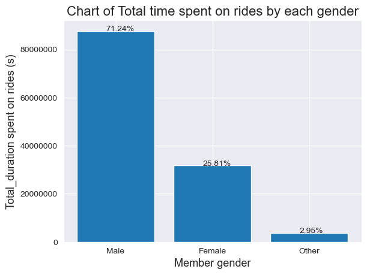

```python
total_time_by_gender = go_bike[['member_gender','duration_sec']].groupby('member_gender', as_index = False).sum()
total_time_by_gender = total_time_by_gender.sort_values(by = 'duration_sec', ascending = False)
color_palette = [sns.color_palette()[0], sns.color_palette()[3], sns.color_palette()[6]]

plt.bar(data = total_time_by_gender, x = 'member_gender', height = 'duration_sec')
plt.ticklabel_format(style = 'plain', axis = 'y')
plt.xticks(rotation = 0)
plt.title('Chart of Total time spent on rides by each gender',fontsize = 16)
plt.xlabel('Member gender', fontsize = 13)
plt.ylabel('Total_duration spent on rides (s)', fontsize = 13)

for i in range(3):
    total = total_time_by_gender['duration_sec'].sum()
    duration = total_time_by_gender.duration_sec[i]
    props = duration/total
    percent = ('{:0.2f}%'.format(props * 100))
    plt.text(i-0.1, duration, percent)
```

#### Insight 12:

Male riders accounted for just over 71% of time spent on rides, while female riders and other gender accounted for about 26% and 3% respectively

### Relationship between variables of interest.

- There is no correlation (positive or negative) between the ages of riders and the time they spend on each ride. Although we can see that there are far more persons below the age of 50 who had rides surpassing 30,000 seconds.
- It was observed that there are far more registered subscribers (8 times more) than there are customers using the bike_sharing service. Furthermore, there are three times more male subscribers than there are female subscribers.
- The faceted histogram plot of age distribution by day of the week shows the age distribution of riders who use the go_ride bike-sharing service on each day of the week. While thursdays generally has the highest number of rides, saturdays and sundays have the least. One important take away from days of the week plot is that there are more riders who are between the ages of 25 and 35.
- The violin plots of both `age vs user_type` and `age vs member_gender` show that a good majority of riders are above the age of 20, but below the age of 40.
- Finally, male riders have cumulatively spend about 71% of the total ride time. This could as well be because there are more than three times more male riders than there are female riders. Further analysis would need to be done to ascertain this hypothesis.

## Multivariate Exploration

> Create plots of three or more variables to investigate your data even further. Make sure that your investigations are justified, and follow from your work in the previous sections.

#### Question 13.

Are male rides really spending more time on rides as the cumulative time spent on rides by different genders suggest? or is the higher total duration of rides as a result of higher number of male riders?

Here one would need need to generate a scatte plot of duration against age, while setting different markers for riders who are male, female or other genders. The presense of a certain marker appearing way up in the chart (higher duration of rides) would mean that the gender represented truly spend more time on a ride on average.

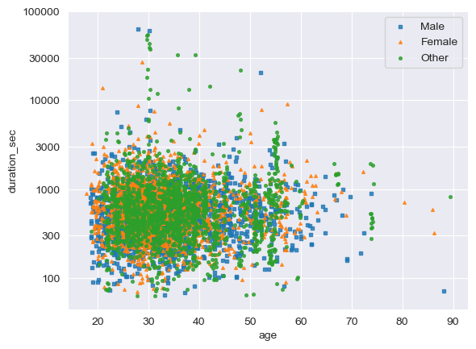

```python
yticks = [100, 300, 1000, 3000, 10000, 30000, 100000]
ylabel = ['{}'.format(v) for v in yticks]

gender_marker = [['Male','s'],
                ['Female','^'],
                ['Other','o']]
for gender, marker in gender_marker:
    plot_data = go_bike[go_bike.member_gender == gender].sample(1740)
    sns.regplot(data = plot_data, x = 'age', y = 'duration_sec', x_jitter = 0.4, fit_reg = False,
               marker = marker, scatter_kws = {'s': 7})
    plt.yscale('log')
    plt.legend(['Male','Female','Other'])

plt.yscale('log')
plt.yticks(yticks, ylabel)
plt.show()
```

It is clear that the higher number of total time spent by the male gender over the female and other genders can only be attributed to the higher number of male riders, not necessarily that male riders, on the average, spend more time on rides.

> One clear point to note though that there are more riders of the other gender who are above the age of 70 than there are either male or female riders.

#### Question 14:

Is there class of user type, accross all age groups, who take longer rides than the other?

Similar to the plot above, we want to know if either of customer or subscriber usertypes take longer rides than the other, irrespective of their age.

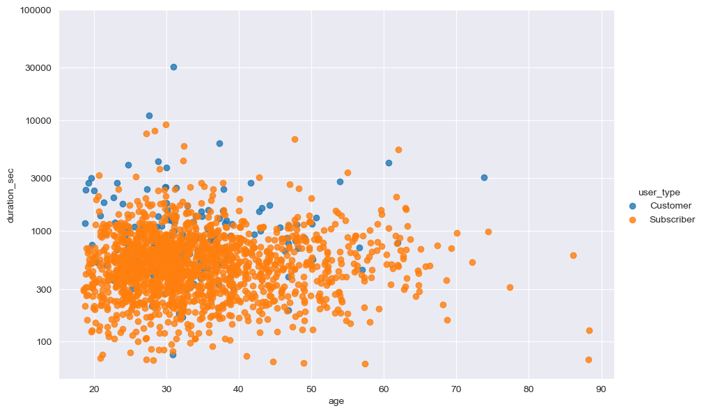

```python
# Plotting a regplot of duration against age, with a hue of user types

yticks = [100, 300, 1000, 3000, 10000, 30000, 100000]
ylabel = ['{}'.format(v) for v in yticks]

g = sns.FacetGrid(data = go_bike.sample(1744), hue = 'user_type', size = 6, aspect = 1.5)
g = g.map(sns.regplot, 'age', 'duration_sec', x_jitter = 0.4, fit_reg = False);
g.add_legend()
plt.yscale('log')
plt.yticks(yticks, ylabel)
plt.show()
```

#### Insight 14:

The clear pattern observed here is that:

- most of the riders above the age of 50 are usually Subscribers. There is no clear pattern as to wether either subscribers or Customers take trips of longer duration than the other.
- subscribers also dominate when it comes to rides below 300 seconds.

It is not clear wether any of the groups take longer rides than the other

### Interactions between the variables of interest.

> There was no clear indication that riders of a specific gender group or user type spend more time on rides than the others. So special attention would not need to be given to any of them. Although there are a lot more male riders than riders of female and other gender, more could be done to improve their inclusion, such as understanding why more women are not using the bike sharing service, and providing services that will attract more of them.

### Interesting interactions between features?

> While we can see that riders of all gender groups and user type basically spend same amount of time on the average, it is surprising that riders of the gender **other** as well as riders who are registered **subscribers** make up the population of riders above 70 years and 50 years of age respectively.

## Conclusions.

Click here to go back to the top of the page